# HFD_data_pulling

Quynh Tran

February 3, 2015

This script is used to pull data from the http://bridgeslab.uthsc.edu/mousedb/ and make a .csv data set for analysis.

The data are saved in ../data/raw/Oxymax export of 2014-10-17 10 week C57BL6J.csv. This script was most recently updated on Mon Apr 6 18:00:27 2015 and is saved in /Users/Quynh/NextGenSeq/ObesityProjects/PredictorsDietInducedObesity/scripts

# Body Weight Analysis

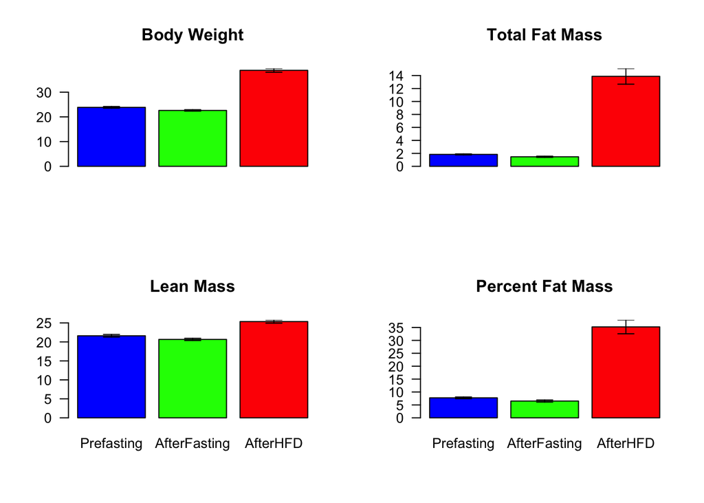

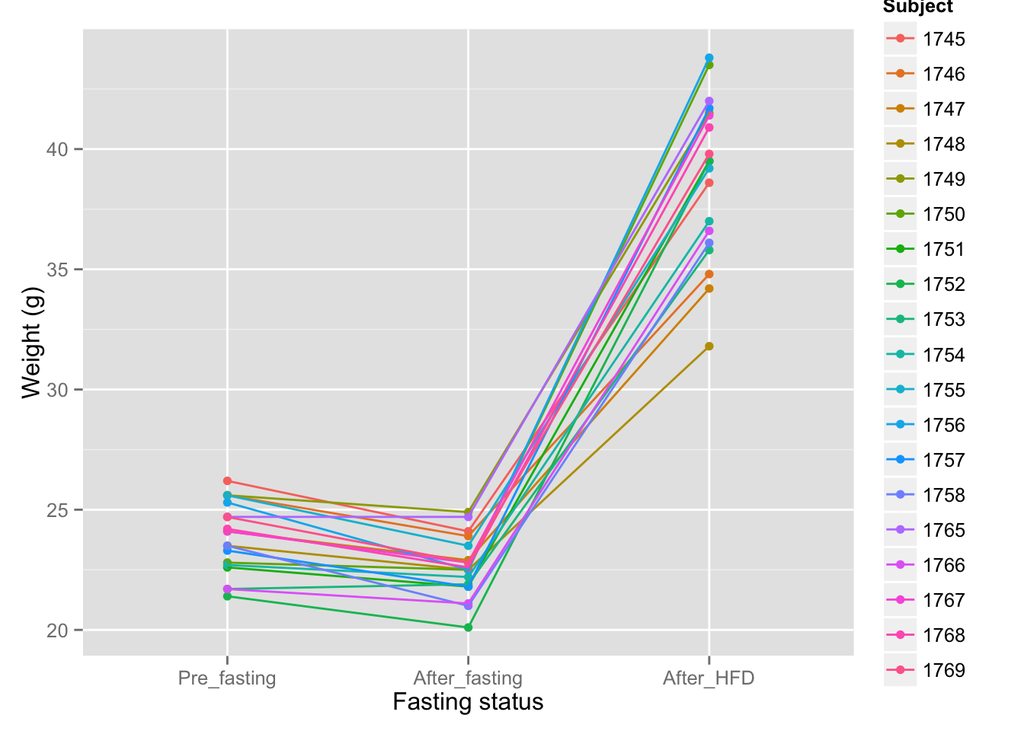

## Body Weight Data Statistics

```r
body.weight.oneway <- data.frame()
body.weight.oneway['Weight','pval'] <- oneway.test(Weight~Fasting_stat, data=cohort8_weight)$p.value
body.weight.oneway['Fat','pval'] <- oneway.test(Fat~Fasting_stat, data=cohort8_weight)$p.value
body.weight.oneway['Lean','pval'] <- oneway.test(Lean~Fasting_stat, data=cohort8_weight)$p.value
body.weight.oneway['Percent.Fat','pval'] <- oneway.test(Percent.Fat~Fasting_stat, data=cohort8_weight)$p.value
body.weight.oneway$padj <- p.adjust(body.weight.oneway$pval, method="BH")
library(xtable)
print(xtable(body.weight.oneway, caption="Oneway ANOVA with Welch correction for effects of Fasting and HFD on Body Composition.  P-values are adjusted by the method of Benjamini and Hochberg", digits=8))
```

[output not shown]

[output not shown]

[output not shown]

[output not shown]

[output not shown]

# VO2 Data

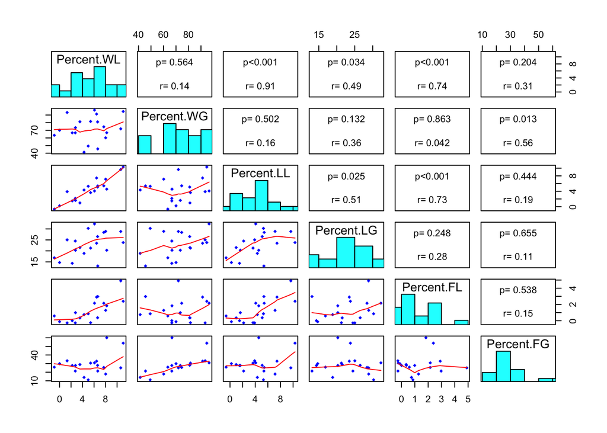

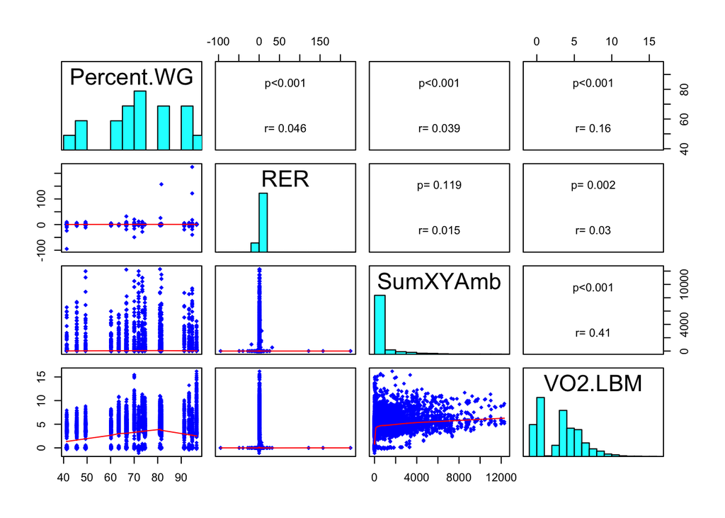

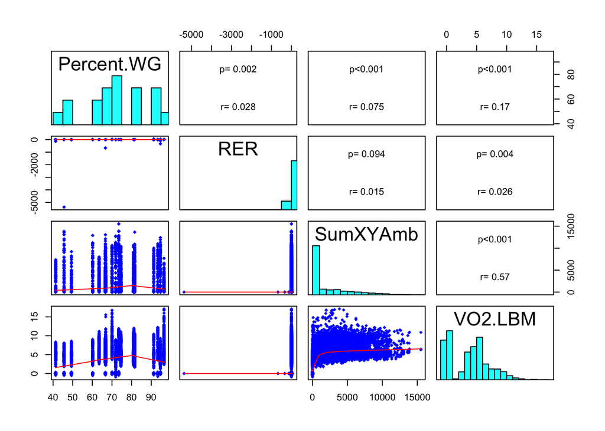

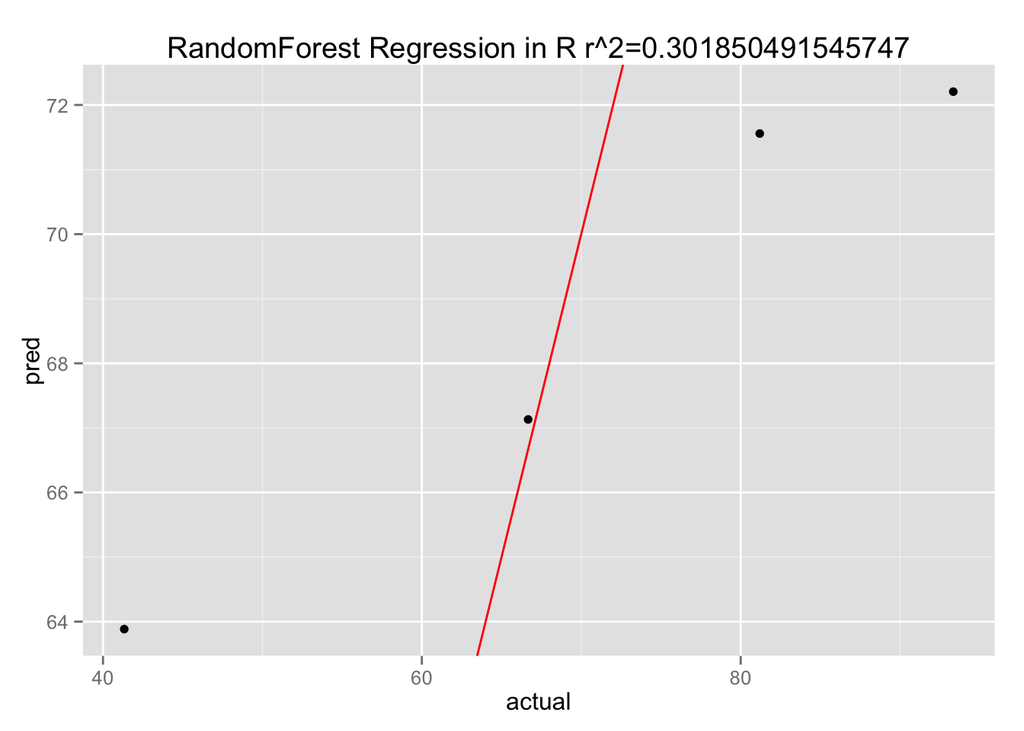

We used random forest to predict the mice weights after HFD. The predictors are Subject, Prefasting weight, After_fasting weight, VO2, RER, Light.Dark, Sum of X and Y ambulatories, and the Fasting status.